# Homework 3: Databases and web scraping

Nikita Reid

2023-05-31

# 1 Money in UK politics

[The Westminster Accounts](https://news.sky.com/story/the-westminster-accounts-12786091), a recent collaboration between Sky News and Tortoise Media, examines the flow of money through UK politics. It does so by combining data from three key sources:

1. [Register of Members’ Financial Interests](https://www.parliament.uk/mps-lords-and-offices/standards-and-financial-interests/parliamentary-commissioner-for-standards/registers-of-interests/register-of-members-financial-interests/),
2. [Electoral Commission records of donations to parties](http://search.electoralcommission.org.uk/English/Search/Donations), and
3. [Register of All-Party Parliamentary Groups](https://www.parliament.uk/mps-lords-and-offices/standards-and-financial-interests/parliamentary-commissioner-for-standards/registers-of-interests/register-of-all-party-party-parliamentary-groups/).

The database, made available by Simon Willison, is an `SQLite` database.

```r
# establish connection to database
# specify driver and database name
sky_westminster <- DBI::dbConnect(
  drv = RSQLite::SQLite(),
  dbname = here::here("data", "sky-westminster-files.db")
)
```

How many tables does the database have? There are 7 tables listed.

```r
# list all tables in the database
DBI::dbListTables(sky_westminster)
```

```
## [1] "appg_donations"  "appgs"           "member_appgs"    "members"
## [5] "parties"         "party_donations" "payments"
```

Which MP has received the most amount of money? Theresa May.

```r
# set up database objects with dplyr for payments, members
# rename id column in members so we have a common member_id column to join the two tables by
members <- tbl(sky_westminster, "members") %>%
  rename(member_id = id)

payments <- tbl(sky_westminster, "payments")

# join the tables to get MP names & payment values in same table
member_payments <- left_join(x=payments, y=members, by = 'member_id')

member_payments %>%
# group by MP name
  group_by(name) %>%
# calculate total money received by each MP
  summarise(total_money = sum(value)) %>%
# arrange to get MP who received most money to top of the table
  arrange(desc(total_money))
```

```
## # Source:     SQL [?? x 2]
## # Database:   sqlite 3.41.2 [/Users/nikitachloereid/Desktop/Homeworks_and_stuff_dsb2023/data/sky-westminster-files.db]
## # Ordered by: desc(total_money)
##    name             total_money
##    <chr>                  <dbl>
##  1 Theresa May         2809765.
##  2 Sir Geoffrey Cox    2191387.
##  3 Boris Johnson       1282402
##  4 Keir Starmer         799936.
##  5 Andrew Mitchell      769373.
##  6 Fiona Bruce          712321.
##  7 John Redwood         692438.
##  8 Rishi Sunak          546043
##  9 Liz Truss            538678.
## 10 Ed Davey             441681.
## # ℹ more rows
```

Is there any `entity` whose donations account for more than 5% of the total payments given to MPs over the 2020-2022 interval? Who are they and who did they give money to?

If we exclude payments made to MPs as “Earnings from other employment” , as I think we should because these are not strictly “donations” , then no entity comes in above 5%. The largest donating entity is Unite with roughly 3.8% of donations in this time period (see first table). Investigating, it seems they donated to a large number of MPs, but donated more than 4 times more to Rebecca Long-Bailey than anybody else (see second table).

If we then go back and include all payment categories, one entity, Withers LLP comes in at roughly 5.8% of total payments to MPs (see third table) and all of these payments were made to a single MP - Sir Geoffrey Cox (see fourth table).

```r
# first we filter and examine only donations (not other earnings)
member_payments %>%
  filter(category_name != "Earnings from other employment") %>%
# collect data into R
  collect() %>%

# separate out date column so we can filter for years 2020-2022 only
  separate(date, into= c("word1", "word2", "month", "year"),sep=" " ) %>%
  filter(year=="2020" | year=="2021" | year=="2022"  ) %>%

# group by entity and remove missing values
  group_by(entity) %>%
  drop_na(value) %>%

# calculate total donations and percentage of total for each entity
# arranged largest to smallest
  summarize(total_donations=sum(value)) %>%
  arrange(desc(total_donations)) %>%
  mutate(percentage=total_donations/sum(total_donations)*100)
```

```
## # A tibble: 1,524 × 3
##    entity                                             total_donations percentage
##    <chr>                                                        <dbl>      <dbl>
##  1 Unite                                                      633313.      3.79
##  2 GMB Union                                                  388738.      2.33
##  3 MPM Connect                                                345217       2.07
##  4 Ministry of Foreign Affairs, Qatar                         242373.      1.45
##  5 The Refugee, Asylum and Migration Policy Project …         239715       1.44
##  6 Lord Waheed Alli                                           218600       1.31
##  7 JBC Defence                                                191100       1.14
##  8 Heathrow Airport                                           175260       1.05
##  9 The Communications Workers Union (CWU)                     168983.      1.01
## 10 The Carlton Club                                           156570       0.938
## # ℹ 1,514 more rows
```

```r
# investigate only highest % entity - Unite
member_payments %>%
  filter(entity=="Unite") %>%

# find out which MPs they donated to and how much to each MP in total
# arranged largest to smallest
  group_by(name) %>%
  summarize(total_donations_Unite=sum(value)) %>%
  arrange(desc(total_donations_Unite))
```

```
## # Source:     SQL [?? x 2]
## # Database:   sqlite 3.41.2 [/Users/nikitachloereid/Desktop/Homeworks_and_stuff_dsb2023/data/sky-westminster-files.db]
## # Ordered by: desc(total_donations_Unite)
##    name                total_donations_Unite
##    <chr>                               <dbl>
##  1 Rebecca Long-Bailey               249382
##  2 Richard Burgon                     58000
##  3 Barry Gardiner                     31517
##  4 Zarah Sultana                      20518.
##  5 Jonathan Reynolds                  16496.
##  6 Ian Lavery                         10882
##  7 Mary Kelly Foy                     10516
##  8 James Murray                        9876.
##  9 Mick Whitley                        9570
## 10 Tracy Brabin                        8953.
## # ℹ more rows
```

```r
# now we examine all payments
member_payments %>%
# collect data into R
  collect() %>%

# separate out date column so we can filter for years 2020-2022 only
  separate(date, into= c("word1", "word2", "month", "year"),sep=" " ) %>%
  filter(year=="2020" | year=="2021" | year=="2022"  ) %>%

# group by entity and remove missing values
  group_by(entity) %>%
  drop_na(value) %>%

# calculate total payments and percentage of total for each entity
# arranged largest to smallest
  summarize(total_payments=sum(value)) %>%
  arrange(desc(total_payments)) %>%
  mutate(percentage=total_payments/sum(total_payments)*100)
```

```
## # A tibble: 2,095 × 3
##    entity                                total_payments percentage
##    <chr>                                          <dbl>      <dbl>
##  1 Withers LLP                                 1812732.      5.83
##  2 Fiona Bruce and Co LLP                       711749.      2.29
##  3 Unite                                        633313.      2.04
##  4 Cambridge Speaker Series                     408200       1.31
##  5 GMB Union                                    388738.      1.25
##  6 Charles Stanley                              346592.      1.11
##  7 MPM Connect                                  345217       1.11
##  8 Centerview Partners LLP                      277724.      0.893
##  9 Council of Insurance Agents & Brokers        276130       0.888
## 10 Hindustan Times                              261652.      0.841
## # ℹ 2,085 more rows
```

```r
# investigate only highest % entity - Withers
member_payments %>%
  filter(entity=="Withers LLP") %>%

# find out which MPs they donated to and how much to each MP in total
  group_by(name) %>%
  summarize(total_payments_Withers=sum(value))
```

```
## # Source:   SQL [1 x 2]
## # Database: sqlite 3.41.2 [/Users/nikitachloereid/Desktop/Homeworks_and_stuff_dsb2023/data/sky-westminster-files.db]
##   name             total_payments_Withers
##   <chr>                             <dbl>
## 1 Sir Geoffrey Cox               1812732.
```

How many distinct entities who paid money to MPS are there?

The authors of the database explicitly state that they have taken care to eliminate duplicates and combine names/entities etc. that they believe to be the same. Hence, I will not brute force any of the entities that “look similar” together because we cannot definitively know they are the same. Hence, 2213 unique entities.

```r
# collect data into R
# and count number of unique entity data values
member_payments %>%
  collect() %>%
  summarise(number_of_unique_entities = n_unique(entity))
```

```
## # A tibble: 1 × 1
##   number_of_unique_entities
##                       <int>
## 1                      2213
```

How many (as a number and %) donated to MPs belonging to a single party only?

2036 entities (~92%)

```r
# group by entity and collect data into R
member_payments %>%
  group_by(entity) %>%
  collect() %>%

# calculate number of parties each entity donated to
  summarize(number_of_parties = n_unique(party_id)) %>%

# create a column to check whether they only donated to a single party id
# and count single party yes versus no
  mutate(single_party = case_when(number_of_parties==1 ~"yes", TRUE ~"no")) %>%
  count(single_party) %>%

# calculate percentages
  mutate(percentage = n/sum(n)*100) %>%

# only display results for entities donating to a single party
  filter(single_party=="yes")
```

```
## # A tibble: 1 × 3
##   single_party     n percentage
##   <chr>        <int>      <dbl>
## 1 yes           2036       92.0
```

## 1.1 Which party has raised the greatest amount of money in each of the years 2020-2022?

```r
# reproducing the figure requested (example figure has been removed here)

# set up database objects with dplyr for donations, parties
# rename id column in parties so we have a common party_id column to join the two tables by
party_donations <- tbl(sky_westminster, "party_donations")

parties <- tbl(sky_westminster, "parties") %>%
  rename(party_id = id)

# join tables to get party names & donation values in same table
party_table <- left_join(x=party_donations, y=parties, by="party_id")

party_table %>%
# use lubridate to extract only year value out of date
  mutate(year=lubridate::year(date)) %>%

# group by year and party
  group_by(year,name) %>%

# calculate total donations and proportion for each party & year
  summarise(total_year_donations=sum(value)) %>%
  mutate(prop =
           total_year_donations/sum(total_year_donations))
```

```
## # Source:   SQL [?? x 4]
## # Database: sqlite 3.41.2 [/Users/nikitachloereid/Desktop/Homeworks_and_stuff_dsb2023/data/sky-westminster-files.db]
## # Groups:   year
##     year name                    total_year_donations    prop
##    <int> <chr>                                  <dbl>   <dbl>
##  1  2020 Alliance                             105000  0.00150
##  2  2020 Conservative                       42770782. 0.612
##  3  2020 Green Party                          378068  0.00541
##  4  2020 Labour                             13539803. 0.194
##  5  2020 Liberal Democrats                  12717295. 0.182
##  6  2020 Plaid Cymru                           70000  0.00100
##  7  2020 Scottish National Party              246284. 0.00352
##  8  2020 Sinn Féin                            113892  0.00163
##  9  2021 Alba Party                            53559. 0.00180
## 10  2021 Alliance                              42500  0.00142
## # ℹ more rows
```

```r
# table image reproduced
```

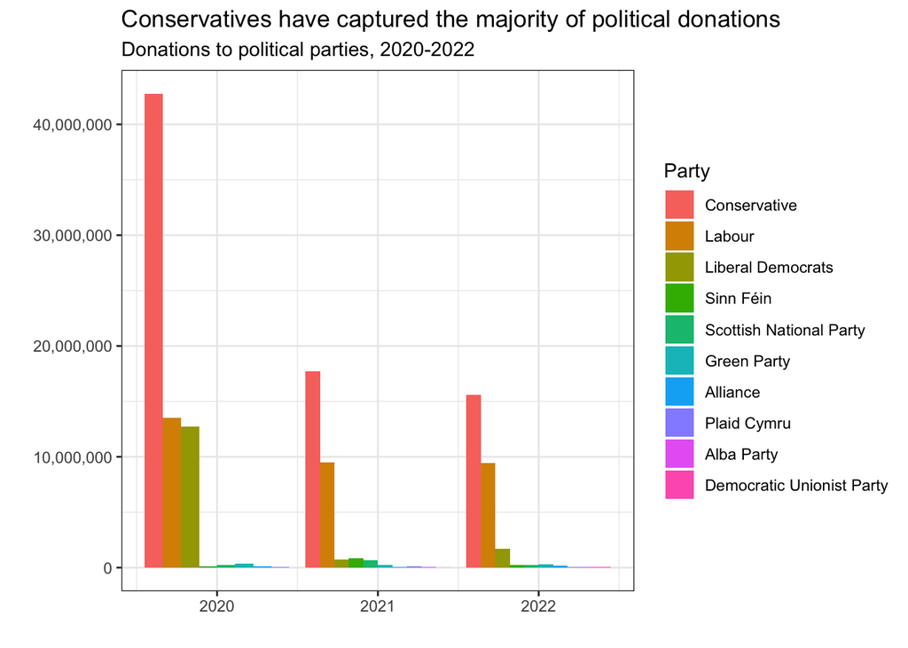

```r
# and now for the graph reproduction requested ...

party_table %>%
# use lubridate to extract only year value out of date
  mutate(year=lubridate::year(date)) %>%

# group by year and party
  group_by(year,name) %>%

# calculate total donations and proportion for each party & year
  summarise(total_year_donations=sum(value)) %>%
  mutate(prop =
           total_year_donations/sum(total_year_donations)) %>%


# bar chart with year on x axis, total donations on y axis
# grouped by party

  ggplot(aes(x=year, y=total_year_donations, fill=name)) +

# rearrange parties according to total donations
  geom_bar(aes(fill=reorder(name,desc(total_year_donations))),
# position party bars side by side
           position="dodge", stat = "identity") +

# make y-axis scientific notation go away
  scale_y_continuous(labels = scales::comma) +

# fix labels and theme as in example figure
  labs(x ="", y ="", fill="Party",
       title = "Conservatives have captured the majority of political donations",
       subtitle = "Donations to political parties, 2020-2022") +
  theme_bw()
```

```r
# graph image reproduced
```

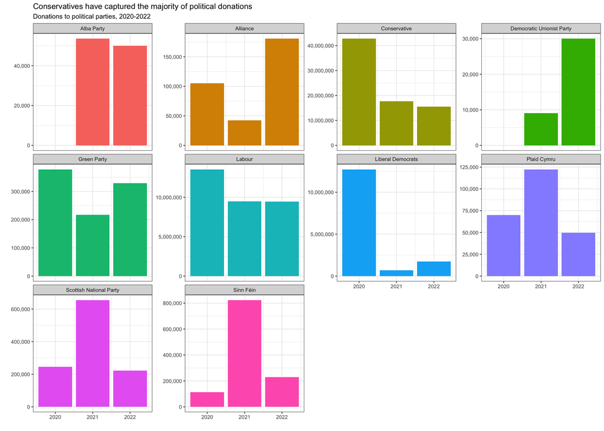

```r
# the same as above using some facetting to make things prettier (maybe?)

party_table %>%
# use lubridate to extract only year value out of date
  mutate(year=lubridate::year(date)) %>%

# group by year and party
  group_by(year,name) %>%

# calculate total donations and proportion for each party & year
  summarise(total_year_donations=sum(value)) %>%
  mutate(prop =
           total_year_donations/sum(total_year_donations)) %>%


# bar chart with year on x axis, total donations on y axis

  ggplot(aes(x=year, y=total_year_donations, fill=name)) +

  geom_bar(position="dodge", stat = "identity") +

# make y-axis scientific notation go away
  scale_y_continuous(labels = scales::comma) +

# fix labels and theme as in example figure
  labs(x ="", y ="",
       title = "Conservatives have captured the majority of political donations",
       subtitle = "Donations to political parties, 2020-2022") +
  theme_bw() +

# now facet wrap by party, make the y scales free and remove legend
  facet_wrap(~name, scales = "free_y") +
  guides(fill="none")
```

```r
# disconnect from the database
dbDisconnect(sky_westminster)
```

# 2 Anonymised COVID patient data from the CDC

We will be using a data set with [anonymous Covid-19 patient data that the CDC publishes every month](https://data.cdc.gov/Case-Surveillance/COVID-19-Case-Surveillance-Public-Use-Data-with-Ge/n8mc-b4w4).

COVID Case Fatality Ratio (CFR %) by age group, sex and ICU Admission

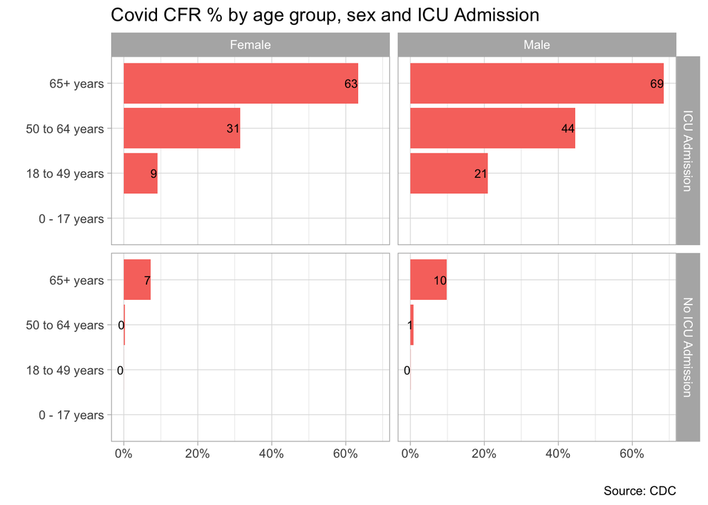

```r
# filter out all missing and unknown data responses
cdc_data %>%
  filter(icu_yn == "Yes"| icu_yn == "No") %>%
  filter(sex=="Male" | sex=="Female") %>%
  filter(age_group != "Missing") %>%
  filter(death_yn != "Unknown" & death_yn != "Missing") %>%

# group by 4 variables: sex, age group, icu admission and death
  group_by(sex, age_group,icu_yn,death_yn) %>%

# collect data into R and remove NA values
# calculate number and percantage of deaths (CFR %) for each group
  summarize(number_death = n()) %>%
  collect() %>%
  drop_na(sex,age_group,icu_yn,death_yn) %>%
  mutate(percentage=number_death/sum(number_death)) %>%

# plot only those who died for the CFR % bars
  filter(death_yn =="Yes") %>%

# create column to fix y axis facet grid labels
  mutate(icu_reformatted = case_when(icu_yn=="Yes" ~ "ICU Admission",
                                     TRUE ~"No ICU Admission")) %>%

# plot bars for CFR % by age_group and use default fill as in example image
  ggplot(aes(x = percentage, y =age_group, fill=death_yn)) +
  geom_bar(stat="identity") +

# 2D facet grid of patient sex versus ICU admission groups
  facet_grid(factor(icu_reformatted, levels = c("ICU Admission",

                                                "No ICU Admission"))~sex) +
# replicate theme and labels from example picture (include caption, remove axes)
  theme_light() +

  labs(x="",y="", caption = "Source: CDC",
       title="Covid CFR % by age group, sex and ICU Admission") +

# fix x-axis into % labels as in example image
  scale_x_continuous(labels=scales::percent) +

# fix y-axis levels to include evn empty age groups as in example image
  scale_y_discrete(limits = c("0 - 17 years", "18 to 49 years",
                              "50 to 64 years", "65+ years")) +
# no legend
  guides(fill="none") +

# add the CFR% text to bars, rounded without decimal places, coloured black
  geom_text((aes(label=(sprintf("%0.0f",percentage*100)))),
            size=3, hjust=1, color= "black")
```

```r
# figure reproduced
```

Now Plot Case Fatality Ratio (CFR) over time:

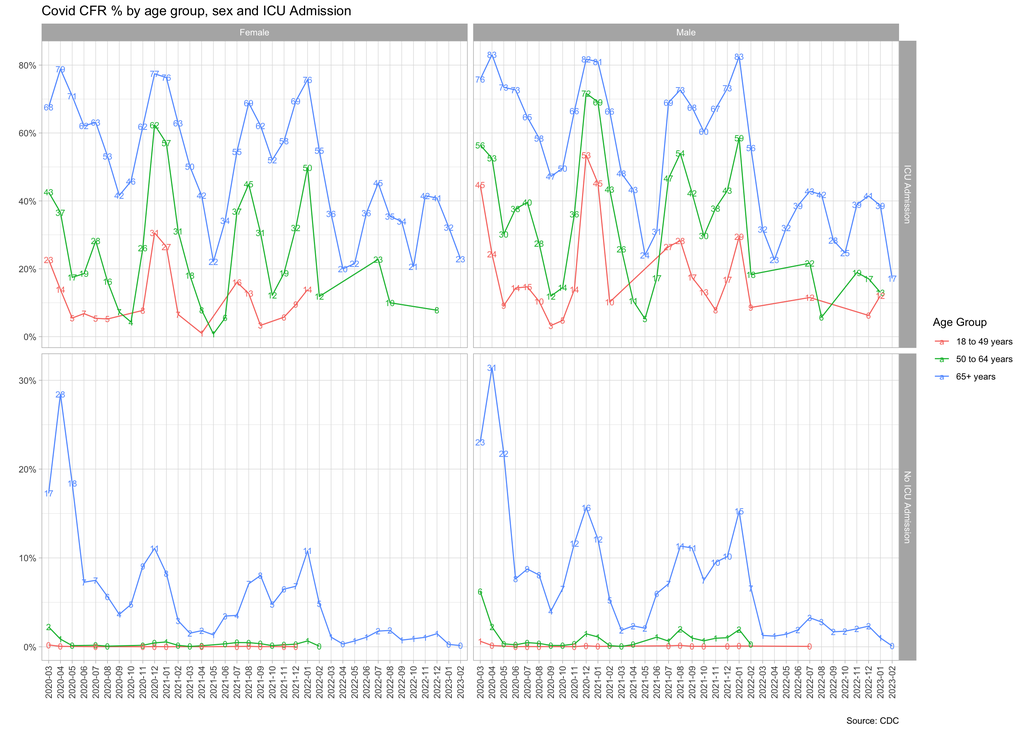

```r
# filter out all missing and unknown data responses
cdc_data %>%
  filter(icu_yn == "Yes"| icu_yn == "No") %>%
  filter(sex=="Male" | sex=="Female") %>%
  filter(age_group != "Missing") %>%
  filter(death_yn != "Unknown" & death_yn != "Missing") %>%
  filter(case_month != "2020-02") %>%

# group by 5 variables: case date (month), sex, age group, icu admission and death
  group_by(case_month,sex, age_group,icu_yn,death_yn) %>%

# collect data into R and remove NA values
# calculate number and percantage of deaths (CFR %) for each group
  summarize(number_death = n()) %>%
  collect() %>%
  drop_na(case_month,sex,age_group,icu_yn,death_yn) %>%
  mutate(percentage=number_death/sum(number_death)) %>%

# plot only those who died for the CFR % points
  filter(death_yn =="Yes") %>%

# create column to fix y axis facet grid labels
  mutate(icu_reformatted = case_when(icu_yn=="Yes" ~ "ICU Admission",
                                     TRUE ~"No ICU Admission")) %>%

# plot lines for CFR %  grouped by age_group
# and use default line color as in example image
  ggplot(aes(x = case_month, y =percentage, group=age_group, color=age_group)) +
  geom_line() +

# 2D facet grid of patient sex versus ICU admission groups
  facet_grid(factor(icu_reformatted, levels = c("ICU Admission",

                                                "No ICU Admission"))~sex,
             scales = "free") +
# replicate theme and labels from example picture (include caption, remove axes)
# vertcally orientate x axis date labels
  theme_light() +
  theme(axis.text.x=element_text(angle=90,hjust=1,vjust=0.5)) +

  labs(x="",y="", caption = "Source: CDC", color="Age Group",
       title="Covid CFR % by age group, sex and ICU Admission") +

# fix y-axis into % labels as in example image
  scale_y_continuous(labels=scales::percent) +

# add the CFR% text to points, rounded without decimal places
  geom_text(aes(label=(sprintf("%0.0f",percentage*100))), size=3)
```

```r
# figure reproduced
```

Case Fatality ratio (CFR) in different counties, according to their population:

```r
# load urban/rural data

urban_rural <- read_xlsx(here::here("data", "NCHSURCodes2013.xlsx")) %>%
  janitor::clean_names()
```

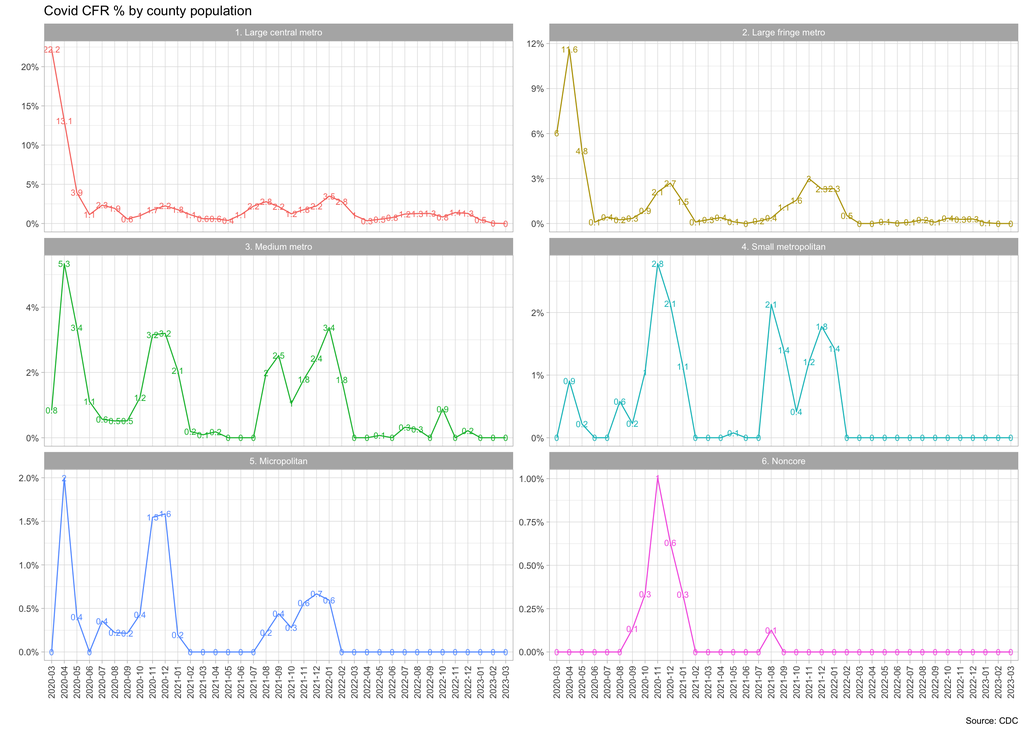

```r
# select columns we need
# filter out all missing and unknown data responses
# group by all selected columns
plot_3 <- cdc_data %>%
  select(sex, age_group, death_yn, icu_yn, case_month, county_fips_code) %>%
  filter(icu_yn == "Yes"| icu_yn == "No") %>%
  filter(sex=="Male" | sex=="Female") %>%
  filter(!is.na(age_group)) %>%
  filter(age_group != "Missing" & age_group != "Unknown" ) %>%
  filter(death_yn != "Unknown" & death_yn != "Missing") %>%
  group_by(sex, age_group, death_yn, icu_yn, case_month, county_fips_code) %>%
# count number of deaths per group and collect into R
  summarise(count = n()) |>
  collect()

# pivot wider to create column that counts yes/no for deaths
plot_3_wide <- plot_3 %>%
  pivot_wider(names_from = death_yn,
              values_from = count) %>%
# clean the data
  janitor::clean_names() %>%
# remove missing values
  drop_na(no) %>%
# create columns that calculates death rate
  mutate(yes = ifelse(is.na(yes),0,yes),
    death_rate = yes/(no+yes))


# join cdc_data and urban_rural data by county fips code
cdc_urban_rural <- left_join(plot_3_wide, urban_rural,
                             by=c("county_fips_code" = "fips_code"))

# remove missing values and group by county and month
cdc_urban_rural %>%
  drop_na(x2013_code) %>%
  group_by(x2013_code, case_month) %>%

# calculate % of people who died per county code/ month
  summarise(total_yes = sum(yes),
            total_no = sum(no),
            percentage = total_yes/(total_yes +total_no)) %>%

# create column to fix facet wrap labels
  mutate(code_reformatted = case_when(x2013_code=="1" ~ "1. Large central metro",
                                     x2013_code=="2" ~"2. Large fringe metro",
                                    x2013_code== "3" ~"3. Medium metro",
                                     x2013_code=="4" ~"4. Small metropolitan",
                                     x2013_code=="5" ~"5. Micropolitan",
                                     x2013_code=="6" ~"6. Noncore")) %>%
# remove unwanted month from plot
  filter(case_month != "2020-02") %>%

# plot lines for CFR % each month
  ggplot(aes(x = case_month, y =percentage, group=code_reformatted,
             color= code_reformatted)) +
  geom_line() +

# facet wrap of county type with three rows as in image
  facet_wrap(~code_reformatted, scales = "free_y", nrow = 3) +

# replicate theme and labels from example picture (include caption, remove axes)
# vertcally orientate x axis date labels
  theme_light() +
  theme(axis.text.x=element_text(angle=90,hjust=3,vjust=0.5)) +

  labs(x="",y="", caption = "Source: CDC",
       title="Covid CFR % by county population") +

# fix y-axis into % labels as in example image
  scale_y_continuous(labels=scales::percent) +

# add the CFR% text to points, rounded
  geom_text(aes(label=(round(percentage*100, 1))), size=3) +

# no legend
  guides(color="none")
```

```r
# figure reproduced
```

Case Fatality ratio (CFR) in urban and rural areas:

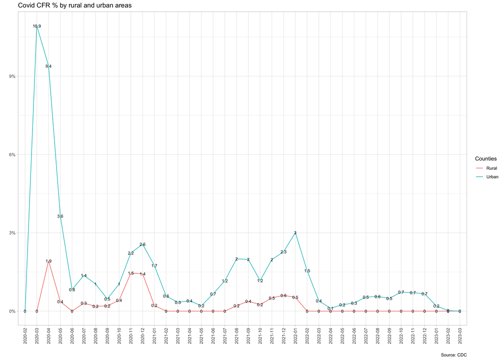

```r
# use cdc urban rural tibble and remove missing values
cdc_urban_rural %>%
  drop_na(x2013_code, county_fips_code) %>%

# column to fix groups to create only "urban" or "rural" category
  mutate(code_urban_rural = case_when(
    x2013_code == 5 | x2013_code == 6 ~ "Rural",
      TRUE ~ "Urban")) %>%

# group by month and urban vs rural
  group_by(code_urban_rural, case_month) %>%

# calculate % of people who died per urban or rural area and month
  summarise(total_yes = sum(yes),
            total_no = sum(no),
            percentage = total_yes/(total_yes +total_no)) %>%

# plot lines for CFR % each month grouped by area
  ggplot(aes(x = case_month, y =percentage, group=code_urban_rural,
             color= code_urban_rural)) +
  geom_line() +

# replicate theme and labels from example picture (include caption, remove axes)
# vertcally orientate x axis date labels
  theme_light() +
  theme(axis.text.x=element_text(angle=90,hjust=3,vjust=0.5)) +

  labs(x="",y="", caption = "Source: CDC", color="Counties",
       title="Covid CFR % by rural and urban areas") +

# fix y-axis into % labels as in example image
  scale_y_continuous(labels=scales::percent) +

# add the CFR% text to points, rounded
  geom_text(aes(label=(round(percentage*100, 1))),
            size=3, color="black")
```

```r
# figure reproduced
```

# 3 Money in US politics

In the United States, [*“only American citizens (and immigrants with green cards) can contribute to federal politics, but the American divisions of foreign companies can form political action committees (PACs) and collect contributions from their American employees.”*](https://www.opensecrets.org/political-action-committees-pacs/foreign-connected-pacs)

All data come from [OpenSecrets.org](https://www.opensecrets.org), a *“website tracking the influence of money on U.S. politics, and how that money affects policy and citizens’ lives”*.

- First, make sure you can scrape the data for 2022:

```r
# is it ok to scrape?

paths_allowed("https://www.opensecrets.org")
```

```
## [1] TRUE
```

```r
base_url <- "https://www.opensecrets.org/political-action-committees-pacs/foreign-connected-pacs/2022"

contributions_tables <- base_url %>%
  read_html() %>%

# scrape all tables on the page
  html_nodes(css="table") %>%
# Turn tables into a dataframe
  html_table()

# we only want the first table
# and clean names into _ (snake_case) format
contributions <- contributions_tables[[1]] %>%
  janitor::clean_names()
```

- Clean the data:

```r
# write a function to converts amounts to numeric values
parse_currency <- function(x){
  x %>%

    # remove dollar signs
    str_remove("\\$") %>%

    # remove all occurrences of commas
    str_remove_all(",") %>%

    # convert to numeric
    as.numeric()
}

# clean country/parent co and contributions into two columns
contributions <- contributions %>%
  separate(country_of_origin_parent_company,
           into = c("country", "parent"),
           sep = "/",
           extra = "merge") %>%

# create new columns using function
  mutate(
    total = parse_currency(total),
    dems = parse_currency(dems),
    repubs = parse_currency(repubs)
  )
```

- Write a function called scrape_pac() :

```r
# define scrape_pac function for given year
scrape_pac <- function(year) {

# set the url of the website we are scraping
  base_url <- "https://www.opensecrets.org/political-action-committees-pacs/foreign-connected-pacs/"

# url combines the base url with whatever year we give
  url <- str_c(base_url, year)

tables <- url %>%
# read the website and get all tables that exist on it
  read_html() %>%

# CSS selector that isolates all tables on the page
  html_nodes(css="table") %>%

# turn table into dataframe
  html_table()


# We only want first table
# and clean names into _ (snake_case) format as before
contributions <-  tables[[1]] %>%
  janitor::clean_names()  %>%

# add new for year
  mutate(year=year) %>%

# from parse_currency function
# two separate columns for country and parent
  separate(country_of_origin_parent_company,
           into = c("country", "parent"),
           sep = "/",
           extra = "merge") %>%

# use parse_currency function to turn contributions into numeric data
  mutate(total = parse_currency(total),
    dems = parse_currency(dems),
    repubs = parse_currency(repubs))

    return(contributions) }
```

- Test scrape_pac() using URLs for 2022, 2020, and 2000 as inputs. Does the function seem to do what you expected it to do?

  It does! The function attaches the chosen year to the back of the base url, scrapes the web page and outputs a data frame containing the contributions (here for each of the years 2022, 2020, 2000) with country and parent column separated, contributions amounts as double precision numerical data and a new column for the year.

```r
# test scrape_pac function by attaching years 2022, 2020, 2000
# in turn to the base url

scrape_pac(2022)
```

```
## # A tibble: 215 × 7
##    pac_name_affiliate                  country parent  total   dems repubs  year
##    <chr>                               <chr>   <chr>   <dbl>  <dbl>  <dbl> <dbl>
##  1 Accenture (Accenture)               Ireland Accen…   3000      0   3000  2022
##  2 Acreage Holdings                    Canada  Acrea…      0      0      0  2022
##  3 Air Liquide America                 France  L'Air…  17300  14800   2500  2022
##  4 Airbus Group                        Nether… Airbu… 193500  82500 111000  2022
##  5 Alexion Pharmaceuticals (AstraZene… UK      Astra… 186250 104000  82250  2022
##  6 Alkermes Inc                        Ireland Alker…  84500  34500  50000  2022
##  7 Allianz of America (Allianz)        Germany Allia…  31500  20500  11000  2022
##  8 AMG Vanadium                        Nether… AMG A…   2525      0   2525  2022
##  9 Anheuser-Busch (Anheuser-Busch InB… Belgium Anheu… 457500 218000 239500  2022
## 10 AON Corp (AON plc)                  UK      AON P…  98500  52000  46500  2022
## # ℹ 205 more rows
```

```r
scrape_pac(2020)
```

```
## # A tibble: 225 × 7
##    pac_name_affiliate                  country parent  total   dems repubs  year
##    <chr>                               <chr>   <chr>   <dbl>  <dbl>  <dbl> <dbl>
##  1 7-Eleven                            Japan   Seven…  20000   1000  19000  2020
##  2 ABB Group (ABB Group)               Switze… Asea …  16900   6800  10100  2020
##  3 Accenture (Accenture)               Ireland Accen…  83500  50500  33000  2020
##  4 Air Liquide America                 France  L'Air…  37800  15800  22000  2020
##  5 Airbus Group                        Nether… Airbu… 182000  79000 103000  2020
##  6 Alkermes Inc                        Ireland Alker…  94750  30750  64000  2020
##  7 Allianz of America (Allianz)        Germany Allia…  71300  36150  35150  2020
##  8 AMG Vanadium                        Nether… AMG A…   2000      0   2000  2020
##  9 Anheuser-Busch (Anheuser-Busch InB… Belgium Anheu… 336500 174000 162500  2020
## 10 AON Corp (AON plc)                  UK      AON P…  80500  44000  36500  2020
## # ℹ 215 more rows
```

```r
scrape_pac(2000)
```

```
## # A tibble: 150 × 7
##    pac_name_affiliate                    country parent total  dems repubs  year
##    <chr>                                 <chr>   <chr>  <dbl> <dbl>  <dbl> <dbl>
##  1 7-Eleven                              Japan   Ito-Y…  8500  1500   7000  2000
##  2 ABB Group                             Switze… Asea … 46000 17000  28500  2000
##  3 Accenture                             UK      Accen… 75984 23000  52984  2000
##  4 ACE INA                               UK      ACE G… 38500 12500  26000  2000
##  5 Acuson Corp (Siemens AG)              Germany Sieme…  2000  2000      0  2000
##  6 Adtranz (DaimlerChrysler)             Germany Daiml… 10500 10000    500  2000
##  7 AE Staley Manufacturing (Tate & Lyle) UK      Tate … 24000 10000  14000  2000
##  8 AEGON USA (AEGON NV)                  Nether… Aegon… 58250 10500  47750  2000
##  9 AIM Management Group                  UK      AMVES… 25000 10000  15000  2000
## 10 Air Liquide America                   France  L'Air…     0     0      0  2000
## # ℹ 140 more rows
```

- Map the `scrape_pac()` function over a vector called `urls` that contains the URLs for each webpage for a given year and write to csv file:

```r
# create urls vector
# year data on webpage comes every two years
urls <- seq(from=2000, to=2022, by=2)

# map this vector and scrape_pac function to a data frame
contributions_all <- map_df(urls, scrape_pac)

# write data frame to csv file in data folder
write.csv(contributions_all, "data/contributions-all.csv")

# now investigate data frame a bit

# let us group by the year donated and who donated
# and see who donated the most
contributions_all %>%
  group_by(year, pac_name_affiliate) %>%

# calculate total donations by year and donating entity (PAC)
# remove missing values and arrange largest donation on top
  summarise(total_donations = sum(total, na.rm=TRUE)) %>%
  arrange(desc(total_donations))
```

```
## # A tibble: 2,378 × 3
## # Groups:   year [12]
##     year pac_name_affiliate         total_donations
##    <dbl> <chr>                                <dbl>
##  1  2020 UBS Americas                       1615000
##  2  2008 Anheuser-Busch                     1505897
##  3  2014 UBS Americas                       1481250
##  4  2022 UBS Americas                       1470000
##  5  2016 UBS Americas                       1445490
##  6  2018 UBS Americas                       1389750
##  7  2020 Toyota Motor North America         1161642
##  8  2022 Toyota Motor North America         1053977
##  9  2006 GlaxoSmithKline                     891413
## 10  2018 Toyota Motor North America          874999
## # ℹ 2,368 more rows
```

# 4 Scraping consulting jobs

The website https://www.consultancy.uk/jobs/ lists job openings for consulting jobs.

```r
# is it ok to scrape?
paths_allowed("https://www.consultancy.uk")
```

- Write a function called `scrape_jobs()` that scrapes information from the webpage for consulting positions:

```r
# define scrape_jobs function for given page
scrape_jobs <- function(page) {

# set the url of the website we are scraping
  base_url <- "https://www.consultancy.uk/jobs/page/"

# url combines the base url with whatever page we want
  url <- str_c(base_url, page)

tables <- url %>%
# read the website and get all tables that exist on it
  read_html() %>%

# CSS selector that isolates all tables on the page
  html_nodes(css="table") %>%

# turn table into dataframe
  html_table()

# We only want first table
jobs <-  tables[[1]]

    return(jobs) }
```

- Test your function works with other pages too. Does the function seem to do what you expected it to do?

  It does work on all pages! Here, it takes page 3 and then page 5 and generates the four column table for the corresponding pages.

```r
# let us test scrape jobs on page 3 and 5
scrape_jobs(3)
```

```
## # A tibble: 45 × 4
##    Job                                             Firm  `Functional area` Type
##    <chr>                                           <chr> <chr>             <chr>
##  1 "Transactions Tax, Senior Consultant \nFTI Con… FTI … "Management\n+5\… Job
##  2 "PH-4762; Senior Project Manager - Sales Expan… B2E … "Sales"           Job
##  3 "Senior Consultant - Cyber Security\nThreeTwoF… Thre… "Cyber Security"  Job
##  4 "Salesforce System Administrator\nGenioo"       Geni… "Data Science\n+… Job
##  5 "Deals | Forensic Accounting - Senior Manager\… PwC   "Forensic & Liti… Job
##  6 "Director, Research Practice\nYonder Consultin… Yond… "Strategy\n+3\nM… Job
##  7 "Director - ER&D Strategy & Transformation (Di… Capg… "Strategy\n+1\nL… Job
##  8 "Senior Consultant, Mergers & Acquisitions\nWe… West… "Mergers & Acqui… Job
##  9 "Senior Consultant Treasury Technology\nZander… Zand… "Corporate Finan… Job
## 10 "Innovation Consultants: All levels\nAyming"    Aymi… "Finance\n+2\nDa… Job
## # ℹ 35 more rows
```

```r
scrape_jobs(5)
```

```
## # A tibble: 45 × 4
##    Job                                             Firm  `Functional area` Type
##    <chr>                                           <chr> <chr>             <chr>
##  1 "Benefits Advisor | Human Resources | Core Ope… FTI … "Human Resources" Job
##  2 "Finance Associate - Accounts Payable, 12 mont… PA C… "Finance"         Job
##  3 "Marketing Executive | Forensic & Litigation C… FTI … "Marketing\n+1\n… Job
##  4 "Financial Services Advisory | Manager | Banki… PwC   "Unknown"         Job
##  5 "Cloud Operating Model - Consultant / Senior C… Capg… "Cloud"           Job
##  6 "Financial Services Advisory | Manager | Banki… PwC   "Unknown"         Job
##  7 "Cloud Strategy - Consultant / Senior Consulta… Capg… "Strategy\n+1\nC… Job
##  8 "PR Manager\nPA Consulting"                     PA C… "Unknown"         Job
##  9 "Executive Assistant, Business Transformation,… FTI … "Unknown"         Job
## 10 "Director, Managed Document Review | Technolog… FTI … "IT Strategy"     Job
## # ℹ 35 more rows
```

- Map the `scrape_jobs()` function over a vector called `pages` in a way that will result in a data frame called `all_consulting_jobs` and write the data frame to a csv file called `all_consulting_jobs.csv` in the `data` folder:

```r
# create pages vector
# for all 8 pages of consulting jobs website
pages <- seq(from=1, to=8, by=1)

# map this vector and scrape_jobs function to a data frame
all_consulting_jobs <- map_df(pages, scrape_jobs)

# write data frame to csv file in data folder
write.csv(all_consulting_jobs, "data/all_consulting_jobs.csv")

# for fun let's investigate which firm has the most open jobs
# group by firm
all_consulting_jobs %>%
  group_by(Firm) %>%

# calculate number of job openings and arrange largest at the top
  count() %>%
  summarise(total_job_openings=n) %>%
  arrange(desc(total_job_openings))
```

```
## # A tibble: 38 × 2
##    Firm              total_job_openings
##    <chr>                          <int>
##  1 PA Consulting                     91
##  2 FTI Consulting                    76
##  3 PwC                               33
##  4 Capgemini Invent                  27
##  5 B2E Consulting                     9
##  6 Valcon                             8
##  7 Yonder Consulting                  8
##  8 Genioo                             6
##  9 ThreeTwoFour                       6
## 10 Ayming                             5
## # ℹ 28 more rows
```